# Welcome

# Introduction

# Electrical Power Systems

##### Nils Jakob Johannesen, PhD.

[figure not shown]

# My office

My office is B-233, on the 2nd floor in the B-building, just above Café Origo.

Contact:

📧nils.j.johannesen@usn.no

🌐 [website](https://www.usn.no/english/about/contact-us/employees/nils-jakob-johannesen)

[interactive chart not shown]

# How to use this book

This is an introduction to how to use this jupyter book.

This jupyter book is an introduction to Electric Power Systems

**Never underestimate the power of revisiting the basic fundamentals**

[Jupyter Book](https://jupyterbook.org/) is an open-source tool used to build books, websites, and documents from a collection of interactive notebooks and Markdown files hosted, developed, and managed as an open-source project on [GitHub](https://github.com/jupyter-book). One such notebook is jupyter notebook. Jupyter Notebook is a free, web-based tool that supports python and lets you write and run live code through live cells, add text explanations and include hyperlinks (hyperreference online links) in markdown cells, so that you can work with data all in one page.

[GitHub](https://github.com/) is a cloud-based platform and website used to manage code. It builds on Git as the underlying tool that runs on your local machine to log file history. [GitHub](https://www.geeksforgeeks.org/git/what-is-github/) allows developers to collaborate on projects, track changes, and maintain a history of all code versions. It is widely used by individual developers, teams, and [organizations](https://github.com/USN-Porsgrunn-Smart-Grid-LAB) to develop software.

### How to Create a GitHub Account

1. Go to https://github.com
2. Click "Sign up".
3. Enter:
   - Email address
   - Password
   - Username (must be unique)
4. Verify your email address when GitHub sends a confirmation email.
5. Complete any verification steps.
6. Choose the Free plan.
7. Finish the setup wizard.

# Build vs. Buy

- The root of the concept originates from Ronald Coase’s 1937 paper [The Nature of the Firm](https://onlinelibrary.wiley.com/doi/full/10.1111/j.1468-0335.1937.tb00002.x), which mathematically defined why companies choose to perform tasks internally ("make") versus using the open market ("buy").
- The **orange** line (*Buying an off-the-shelf solution*): Illustrates the ongoing effort when choosing a proprietary, ready-to-use product. Initially, effort and costs are low as the system is ready to deploy. Over time, however, time and resource consumption increase drastically because the company is tied to the vendor's framework (vendor lock-in), making it highly demanding and expensive to add new, customized functionality.
- The **blue** line (*Building from scratch*): Illustrates the trajectory if you invest in developing a proprietary solution from the ground up. This requires a large investment and high effort in the initial phase. Over time, however, the effort decreases significantly because the system is built on open standards and is interoperable. This makes it far easier and more cost-effective to further develop functionality later (payback).
- Open-source models and agentic frameworks now allow any company to assemble what it once had to buy. What is known as the [SaaSpocalypse](https://medium.com/procurement-tidbits/the-saaspocalypse-is-real-the-conclusions-being-drawn-from-it-are-not-665e9ccf0ae5) refers to a significant downturn and valuation drop in the Software as a Service (SaaS) industry caused by AI advancements.
- Having the capacity to build your own software is indeed a [differentiator](https://medium.com/chick-fil-atech/ea-principles-addendum-build-vs-buy-4b584ac076bf).

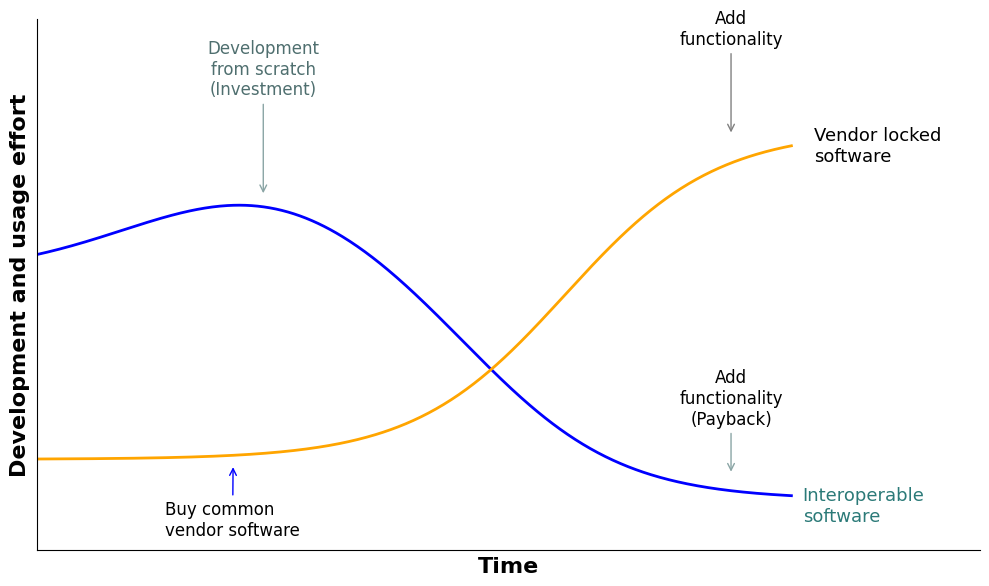

**Mandatory Courses (160 ECTS) Bsc El Eng at USN**

| Fall 2026 | Spring 2027 | Fall 2027 | Spring 2028 | Fall 2028 | Spring 2029 |
| --- | --- | --- | --- | --- | --- |
| **Digital Technology** PB1130 · 5 ECTS · Mandatory | **Mathematics 1** IB1030 · 10 ECTS · Mandatory | **Mathematics 2** PB2010 · 10 ECTS · Mandatory | **Statistics** PB2030 · 5 ECTS · Mandatory | **Electrical Machines** TSE3080 · 10 ECTS · Mandatory | **Interdisciplinary Project Work** IB3010 · 10 ECTS · Mandatory |
| **Electrical Engineering 1** PB1120 · 5 ECTS · Mandatory | **Physics 1 – Mechanics** PB1010 · 5 ECTS · Mandatory | **Physics 2 – Electromagnetism** PB2060 · 5 ECTS · Mandatory | **Chemistry** TS2010 · 5 ECTS · Mandatory |  | **Bachelor Thesis** TS3000 · 20 ECTS · Elective |
| **Low Voltage Engineering** PB1160 · 10 ECTS · Mandatory |  | **Programmable Logic Control (PLC)** TSE2160 · 5 ECTS · Mandatory | **Automation and Hydropower Regulation** TSE2210 · 10 ECTS · Mandatory |  | **Student Enterprise** TS3010 · 20 ECTS · Elective |
| **Object-Oriented Programming and Databases** PB1150P· 10 ECTS · Mandatory |  | **Electrical Safety** TSE2170 · 10 ECTS · Mandatory | **Electric Power Systems** TSE2220 · 10 ECTS · Mandatory |  |  |
| **Programming for Scientific Computing** IB1020 · 5 ECTS · Mandatory | **Electrical Engineering 2** PB1140P · 5 ECTS · Mandatory |  |  |  |  |
| **The Engineering Profession** IB1010 · 5 ECTS · Mandatory |  |  |  |  |  |

##### Note: 6th semester (Spring 2029)

Students must choose at least one of: Bachelor Thesis (TS3000)/Student Enterprise (TS3010)

## Elective Courses (20 ECTS)

| Fall 2028 | Spring 2029 |
| --- | --- |
| **High Voltage Technology** VE3320 · 10 ECTS · 1 semester · Elective | **Mathematics 3 – Digital** VE3010D · 10 ECTS · 1 semester · Elective |
| **Elective Exchange Semester** ING3 UTV · 30 ECTS · 1 semester · Elective |  |
| **Mathematics 3** VE3010 · 10 ECTS · 1 semester · Elective |  |
| **Engineering Internship** VE3040 · 10 ECTS · 1 semester · Elective |  |
| **Entrepreneurship** VE3050 · 10 ECTS · 1 semester · Elective |  |
| **Introduction to Machine Learning and Artificial Intelligence** VE3451 · 10 ECTS · 1 semester · Elective |  |

# Power System Data

Experts on power systems considers the [3D's](https://www.sciencedirect.com/science/article/pii/S1364032118304283) (Decarbonisation, Decentralisation and Digitalisation) as drivers for the changes in the power system infrastructure. Theese and other [D'frames](https://www.sciencedirect.com/science/article/pii/S2214629621003236#b0140) are anaylytical frames to understand the trends governing the increasingly compex future power system. Power system data provides the facts and the underlaying numbers.

[interactive chart not shown]

## Digitilasation

Although [digitalisation](https://www.irena.org/-/media/Files/IRENA/Agency/Publication/2025/Oct/IRENA_INN_Digitalisation_AI_for_power-systems_2025.pdf) is an enabler of electrification and decarbonisation, its share of the total electricity demand is concerning:

[interactive chart not shown]

To get knowledge of the power system we can acess open data sources from the Transmission System Operators (TSO). In Norway the TSO is Statnett. The TSO operates the transmission system and is responsible for transmitting and balancing power and maintaining and developing the transmission infrastructure. Statnett gathers [data from the power system](https://www.statnett.no/en/for-stakeholders-in-the-power-industry/data-from-the-power-system/) and provide an overview of how the power system operates. Statnett is part of the European Network of Transmission Sytem Operators ([ENTSO-E](https://www.entsoe.eu/)), together with 40 other TSO's from Europe. On ENTSO-E [transparency platform](https://transparency.entsoe.eu/) european power system data is published.

## Data Overview (Norway)

### Key Figures for the Power System (2025)

Based on the NVE report: [Status and development in the power system 2025–2030](https://publikasjoner.nve.no/rapport/2026/rapport2026_17.pdf)

| Variable | Value |
| --- | --- |
| Production | approx. 161.8–162 TWh |
| Consumption | approx. 138–139 TWh |
| Power surplus | approx. 22–23 TWh |
| Share hydropower | ~90% |
| Share wind power | ~8–9% |
| Share solar | ~0.2% |
| Fossil / thermal | ~1% |

### Links to power system data

| Source | Link |
| --- | --- |
| National Renewable Energy Laboratory (NREL) | https://github.com/NatLabRockies/hsds-examples |

# Fundamentals

Fundamental to electrical power systems, is to define the time aspect.

We start with the generic sinusoidal function and recall Euler’s formula:

$$ e^{j\theta} = \cos\theta + j\sin\theta $$

In this book, we use MKS units and IEEE standards as far as possible.

## The MKS System

The meter–kilogram–second (MKS) system is a system of units where the fundamental units are:

- Length: meter (m)
- Mass: kilogram (kg)
- Time: second (s)

MKS means that all physical quantities are constructed from meter, kilogram, and second, and this forms the basis of the SI units used in power systems.

For example:

$$ 1 \, V = \frac{kg \cdot m^2}{s^3 \cdot A} $$

All physical quantities in power systems are expressed in SI units (MKS-based):

- Voltage: Volt
- Current: Ampere
- Power: Watt
- Impedance: Ohm

## Per-Unit System

The per-unit system normalizes MKS values by dividing by a chosen base value, producing dimensionless quantities:

$$ x_{pu} = \frac{x_{MKS}}{x_{base}} $$

### Base Quantities

From the base values $S_{base}$ (VA) and $V_{base}$ (Volt), we can derive:

$$ I_{base} = \frac{S_{base}}{\sqrt{3} V_{base}} $$

$$ Z_{base} = \frac{V_{base}^2}{S_{base}} $$

## Time Domain and Phasors

The time-domain representation of voltage can be expressed as:

$$ v(t) = \hat{V} \cdot \cos(\omega t) $$

Lowercase letters (e.g., $v$) are used to represent instantaneous values that vary as a function of time ($t$), while uppercase letters ($V$) represent constant quantities.

The representation of time-varying and constant quantities is not standardized in the same way as MKS, SI, and IEEE. Instead, it is based on conventions—agreements developed over time about how to express these quantities. This is also a good illustration of the difference between standards and conventions.

Here:

- $\hat{V}$ is the voltage amplitude
- $f$ is the frequency (typically 50 Hz, i.e., 50 cycles per second)

In the Python script below, `V_ampl` represents the constant amplitude, while $v(t)$ varies as a function of time.

[figure not shown]

In this way, the cosine representation describes the system under continuous operation from a steady-state perspective. The steady-state perspective is also important when the vector ($V$) rotates in the time domain and becomes a phasor representation.

## Time Domain (Waveform) and Rotating Vector (Phasor)

The phasor representation becomes particularly useful when analyzing phase shifts, for example in three-phase systems or current phase shifts caused by passive components:

$$ v(t) = \hat{V} \cdot \sin(\omega t) \Longleftrightarrow \bar{V} = \hat{V} \angle \theta $$

[figure not shown]

We use the notation $\bar{V}$ to indicate that this is a complex number with a magnitude (amplitude $\hat{V}$) and a phase ($\theta$). The magnitude is also called the absolute value $|V|$, while the phase is the argument of the complex number.

In power systems, the convention is to use the cosine representation due to the steady-state perspective discussed above.

[figure not shown]

$$ \Re\{e^{j\omega t}\} = \cos(\omega t) $$

- no additional phase
- the phasor points along the x-axis at $t = 0$

$$ \Im\{e^{j\omega t}\} = \sin(\omega t) $$

However, in this case:

- at $t = 0$: value = 0
- you do not "see" the vector directly

When using the real part:

$$ v(t) = \Re\{V e^{j\omega t}\} $$

the relationship becomes:

$$ V = |V| e^{j\theta} $$

completely direct.

### Result:

$$ v(t) = |V| \cos(\omega t + \theta) $$

- the phase $\theta$ is exactly the same as in the phasor
- no additional shift

With sine, you must write:

$$ v(t) = |V| \sin(\omega t + \theta) $$

which is actually:

$$ = |V| \cos(\omega t + \theta - 90^\circ) $$

that is:

$$ V = |V| e^{j(\theta - 90^\circ)} $$

View in animation:

# Cosine and sine

[figure not shown]

## Root Mean Square (RMS)

RMS stands for “root mean square” and represents the effective value of a signal.

For an alternating voltage, a simple average cannot be used because it becomes zero. Instead, we square the signal, take the average, and then take the square root. This yields a value equivalent to the DC voltage that would produce the same power.

For a sinusoidal signal:

$$ V_{RMS} = \frac{\hat{V}}{\sqrt{2}} $$

When we say 230 V in a power outlet, this refers to the RMS value—that is, the value that determines how much energy is delivered.

The actual waveform is:

$$ v(t) = 325 \sin(\omega t) $$

For a general signal $x(t)$:

$$ X_{RMS} = \sqrt{\frac{1}{T} \int_0^T x^2(t)\, dt} $$

Thus, we obtain:

$$ V_{RMS} = \frac{\hat{V}}{\sqrt{2}}, \quad I_{RMS} = \frac{\hat{I}}{\sqrt{2}} $$

The voltage we measure is 230 V, but the amplitude is:

$$ \hat{V} = V \cdot \sqrt{2} = 230 \cdot \sqrt{2} \approx 325 \text{ V} $$

The term $\cos \theta$ is used to describe phase shift, and if it is known, we can directly calculate power:

$$ P = V_{RMS} I_{RMS} \cos\theta $$

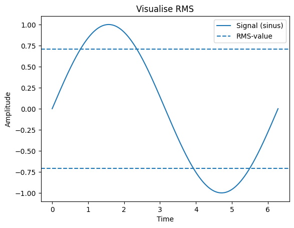

# Basic representations

Knowing the angular freqency, $\omega$, a phasor can be re-transformed into the time-domain.

Phasors lets us convert differential equations into algebraic equations using complex variables.

To calculate the current in the figure below it is solved in the time-domain using differential equations:

$$ Ri(t) + L\frac{di}{dt} +\frac{1}{C}\int i(t) dt = \sqrt{2} V cos(\omega t)$$

[figure not shown]

# Phasor convertions

We can redraw the circuit using phasors; the inductance L is represented by $j\omega L$ and capacitance C by $j(\frac{1}{-\omega C})$

$$ R + jX_L - jX_C$$

[figure not shown]

# Impedance triangle

The impedance triangle illustrates the effect of inductance and capacitance on the impedance

[figure not shown]

[figure not shown]

**André‑Marie Ampère**  
1820–1826

Electric current produces magnetic fields. Foundation of electric motors and generators.

[figure not shown]

**Michael Faraday**  
1831

Electromagnetic induction. Foundation of generators and transformers.

[figure not shown]

**James Clerk Maxwell**  
1861–1865

Unified electromagnetism through Maxwell's equations.

```
●────────────●────────────●────────────●────────────●
1820         1827         1831         1845         1865
```

[figure not shown]

**Georg Simon Ohm**  
1827

Relationship between voltage, current, and resistance.

[figure not shown]

**Gustav Kirchhoff**  
1845

Laws for analyzing electrical circuits and power systems.

IMAGE CREDITS

All portraits are courtesy of Wikimedia Commons.

1. André‑Marie Ampère https://commons.wikimedia.org/wiki/File:Ampere_portrait_at_the_Musee_Poleymieux.jpg
2. Georg Simon Ohm https://commons.wikimedia.org/wiki/File:Georg-simon-ohm2.jpg
3. Michael Faraday https://commons.wikimedia.org/wiki/Michael_Faraday
4. Gustav Robert Kirchhoff https://commons.wikimedia.org/wiki/File:Gustav_Robert_Kirchhoff.jpg
5. James Clerk Maxwell https://commons.wikimedia.org/wiki/File:James_Clerk_Maxwell_profile.jpg

# Electric circuits

There are five basic circuit elements:

- voltage sources
- current sources
- resistors
- inductors
- capacitors

A resistor is described mathematically using its voltage and current, and the relationship is known as **Ohms's law**

$$ v = i \cdot R$$

v = voltage i = current R = resistor

# The power equation:

$$ p = v \cdot i$$

where p = the power in watts, v = the voltage in volts, i = the current in amperes, is derived from the definition of power:

$$ p = \frac{dw}{dt} = \frac{dw}{dq}\cdot\frac{dq}{dt} $$

w = the energy in joules, and t = the time in seconds.

The power in a resistor in terms of current is:

$$ p = i^2R$$

The power in a resistor in terms of voltage is:

$$ p = \frac{v^2}{R}$$

## Laws for Circuit analysis

The two fundamental laws for analysing electric circuits are Kirchoffs law.

### Kirchoff's current law (KCL)

Kirchoff's law of currents (KCL) states that that the algebraic sum of currents entering a node is zero.

$$ \sum_{n=1}^N i_n = 0 $$

where N is the number of branches connected to the node and is the nth current entering (or leaving) the node. By this law, currents entering a node may be regarded as positive, while currents leaving the node may be taken as negative or vice versa.

or:

$$ \sum i_{in} = \sum i_{out} $$

and as depicted in the figure:

$$ i_1+i_2+i_3+i_4=i_5 $$

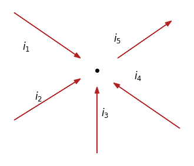

### Kirchhoff's voltage law (KVL)

Kirchhoff's voltage law (KVL) states that the algebraic sum of all voltages around a closed path (or loop) is zero. Expressed mathematically:

$$ \sum_{m=i}^M v_m = 0 $$

where M is the number of voltages in the loop (or the number of branches in the loop) and $v_m$ is the mth voltage.

The sign on each voltage is the polarity of the terminal encountered first as we travel around the loop. We can start with any branch and go around the loop either clockwise or counterclockwise.

If we start with the voltage source, $v_1$ and go clockwise around the loop as shown; then voltages would be $-v_1+v_2+v_3$ and in that order. For example, as we reach branch 3, the positive terminal is met first; hence, we have $+v_3$. For branch 4, we reach the negative terminal first; hence $-v_4$, Thus, KVL yields

$$-v_1 + v_2 + v_3 -v_4 +v_5 = 0$$

and rearranged:

$$v_2+v_3+v_5 = v_1+v_4$$

interpreted as: **Sum of voltage drops = Sum of voltage rises**

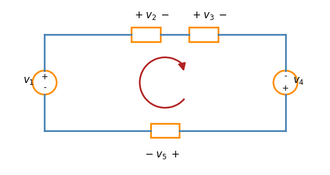

## Methods for Circuit analysis

- Nodal analysis (based on a systematic application of KCL)
- Mesh analysis (based on a systematic application of KVL)

The two techniques are so important that they should be regarded as the most important in circuit analysis.

### Mesh Analysis

Nodal analysis applies KCL to find unknown voltages in a given circuit, while mesh analysis applies KVL to find unknown currents.

```
A mesh is a loop which does not contain any other loops within it.
```

#### Steps to Determine Mesh Currents:

1. Assign mesh currents to the n meshes.
2. Apply KVL to each of the n meshes. Use Ohm’s law to express the voltages in terms of the mesh currents.
3. Solve the resulting n simultaneous equations to get the mesh currents.

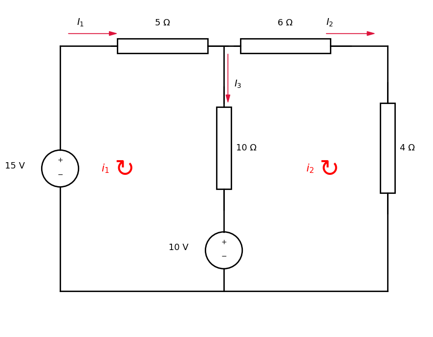

1. In the example above the n mesh currents is n = 2, we assign $i_1$ and $i_2$ to the mesh currents.
2. Apply KVL on mesh 1:

$$-15 + 5\cdot i_1 + 10(i_1-i2) + 10 = 0 $$

$$ 15\cdot i_1 -10\cdot i_2= 5 $$

$$3\cdot i_1 -2\cdot i_2 = 1$$ Apply KVL on mesh 2: $$ -10 + 10(i_2-i_1) +6\cdot i_2 + 4\cdot i_2 = 0$$

$$ -10\cdot i_1 + 20\cdot i_2 = 10 $$ $$ -1\cdot i_1 + 2 \cdot i_2 = 1 $$ We have to sets of equations $$ \begin{aligned} 3i_1 - 2i_2 &= 1 \\ -i_1 + 2i_2 &= 1 \end{aligned} $$

There are 3 methods that can solve this:

1. Substitution method
2. Cramers rule
3. Matrix inversion

We can put on standard matrix form **Ai=b**

$$ \begin{bmatrix} 3 & -2 \\ -1 & 2 \end{bmatrix} \begin{bmatrix} i_1 \\ i_2 \end{bmatrix} = \begin{bmatrix} 1 \\ 1 \end{bmatrix}$$

And solve by matrix inversion:

```python
A = np.array([[3, -2],[-1,2]])
b = np.array([[1],[1]])
A_inv = np.linalg.inv(A)
i = A_inv @ b
print('The first mesh i_1=', np.round(i[0,0]))
print('The second mesh i_2=', np.round(i[1,0]))
```

```
The first mesh i_1= 1.0
The second mesh i_2= 1.0
```

# Mesh analysis for polyphase systems

Mesh analysis can be elegantly applied to solve circuit problems in polyphase systems

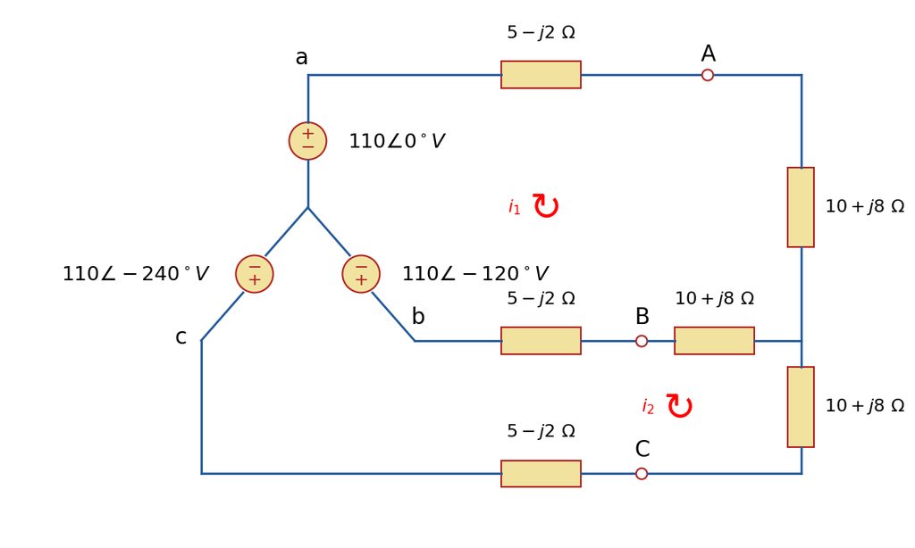